# Chap9.1

Mijeong Kim

```r
library(tsibble)
library(tsibbledata)
library(tibble)
library(dplyr)
library(knitr)
library(ggplot2)
library(fpp3)
library(fpp2)
library(seasonal)
library(feasts)
```

# Chapter 9: ARIMA 모델

- ARIMA(자기회귀 누적 이동평균) 모델은 시계열 예측을 위한 대표적인 방법 중 하나이다.
- **지수 평활법(exponential smoothing)**과 함께 시계열 예측에서 가장 널리 사용되는 두 가지 접근법이다.
- 지수 평활은 **추세(trend)**와 **계절성(seasonality)**에 초점을 맞추는 반면, ARIMA는 데이터의 자기상관(autocorrelation) 구조를 설명하는 데 중점을 둔다.
- ARIMA 모델을 도입하기 전에, 먼저 정상성(stationarity) 개념과 차분(differencing) 기법을 이해해야 한다.

## 9.1 Stationarity and differencing

ARIMA 모델을 이해하기 위해서는 **정상성(stationarity)**의 개념이 매우 중요하다.

정상성 시계열

- 추세(trend)가 없음
- 분산이 일정함
- 평균이 시간에 따라 변화하지 않음
- 자기상관 구조도 변하지 않음.

비정상 시계열의 특징

주의할 점: (g)의 경우

- 7. 시계열은 주기적(순환)인 변동이 강하게 보이나, 이는 비정기적인(a-periodic) 순환이다.
- 캐나다 스라소니(lynx) 개체 수의 주기적 변동은 먹이 부족 → 개체 수 감소 → 먹이 회복 → 개체 수 증가로 이어지는 비정기적 순환이며, 이는 장기적으로 예측 불가능하다.
- 따라서 (g)는 정상성 시계열로 간주할 수 있다.

### 차분(Differencing)

차분이란?

- 연속 관측값의 차이를 계산하여 시계열의 **수준 변화(level shift)**나 **추세(trend)**를 제거하는 방법이다.
- **평균을 안정화(stabilise the mean)**시키고, 추세나 계절성을 감소시킬 수 있다.
- 로그 변환 등은 분산을 안정화하는 데 도움을 줄 수 있다.

정상성 판단: ACF 플롯 활용

- 정상 시계열: ACF(자기상관 함수)가 빠르게 0으로 수렴
- 비정상 시계열: ACF가 천천히 감소, 첫 번째 지연값 $r_1$이 크고 양수인 경우가 많음

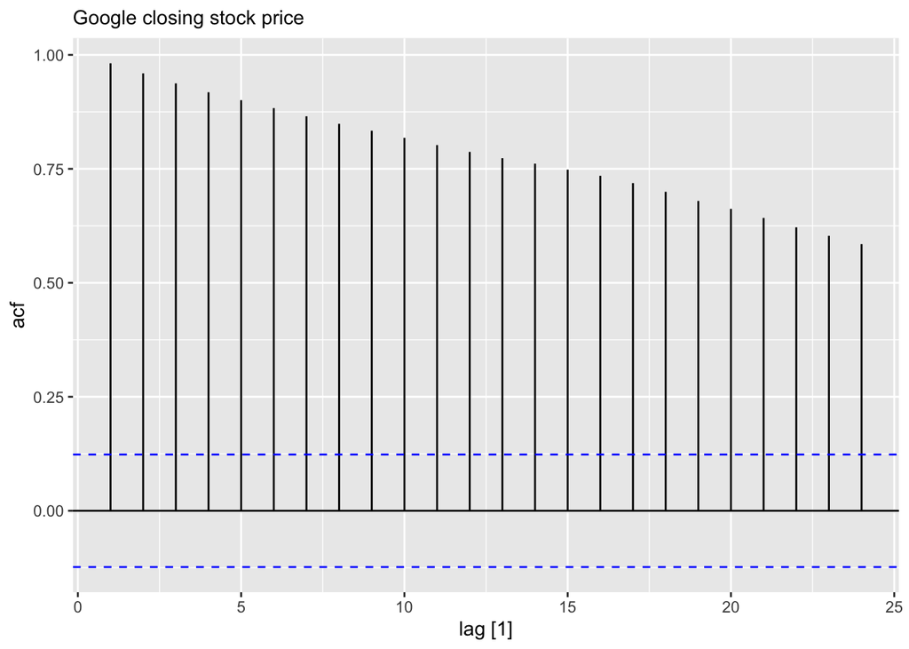

```r
google_2015 <- gafa_stock |>
  filter(Symbol == "GOOG", year(Date) == 2015)
google_2015 |> ACF(Close) |>
  autoplot() + labs(subtitle = "Google closing stock price")
```

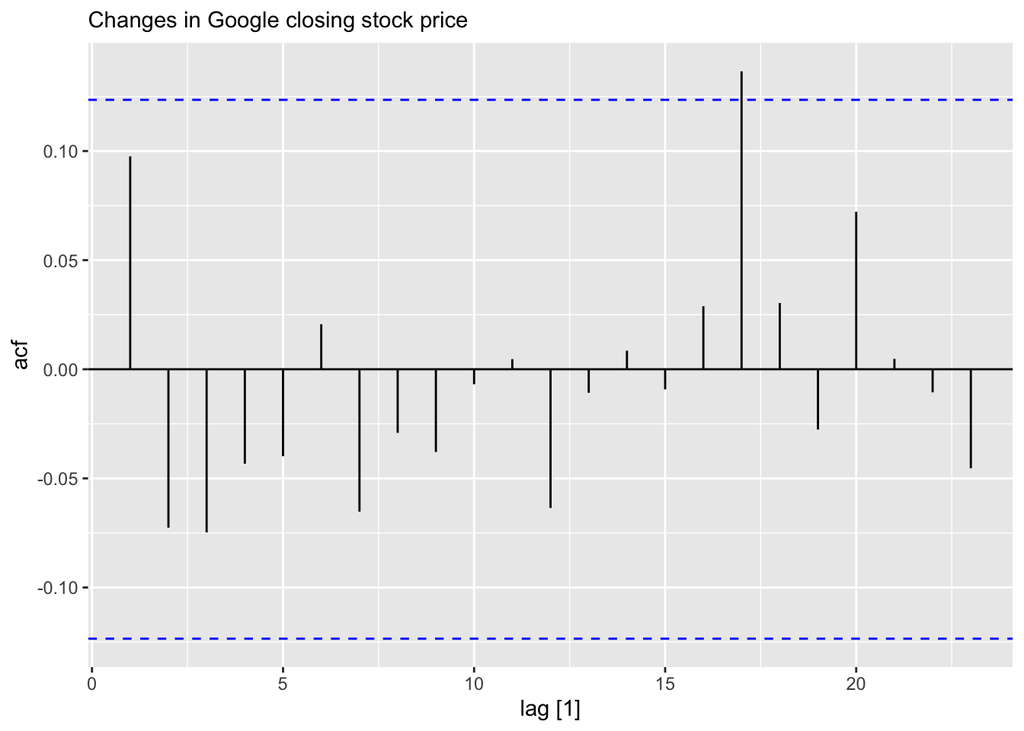

```r
google_2015 |> ACF(difference(Close)) |>
  autoplot() + labs(subtitle = "Changes in Google closing stock price")
```

Figure 9.2: The ACF of the Google closing stock price in 2015 (left) and of the daily changes in Google closing stock price in 2015 (right).

```r
google_2015 |>
  mutate(diff_close = difference(Close)) |>
  features(diff_close, ljung_box, lag = 10)
```

```
## # A tibble: 1 × 3
##   Symbol lb_stat lb_pvalue
##   <chr>    <dbl>     <dbl>
## 1 GOOG      7.91     0.637
```

Google 주가의 **일일 변화량(differenced series)**은 다음 특징을 보인다:

- ACF 플롯은 **백색 잡음(white noise)**와 유사
- 자기상관 계수 중 **단 하나만이 95% 신뢰구간을 벗어남**

#### Ljung-Box 검정 결과

- 예시: Ljung-Box 검정 결과 가정
- 실제 분석에서는 Box.test() 또는 feasts 패키지 사용

Ljung-Box Q* 통계량의 p-value = 0.637 (h = 10)

유의수준 0.05보다 훨씬 크므로 귀무가설 채택 → 자기상관 없음, 즉 **무작위성(randomness)**이 강함

### Random walk model

#### 1. 차분(Differencing)

- **차분**은 원래 시계열의 연속 관측값 간 차이를 계산한 것이다.

$$y'_t = y_t - y_{t-1}$$

- **T개의 시계열 → 차분 시 T−1개의 값 생성**
- **평균 안정화** 및 **추세 제거**에 유용

#### 2. 랜덤 워크 모델 (Random Walk)

- 차분 시계열이 백색잡음이라면, 원 시계열은 **랜덤 워크 모델**로 표현된다:

$$y_t = y_{t-1} + \varepsilon_t$$

- 예측값은 마지막 관측값과 동일하며, **변화 방향은 예측 불가능**
- 이는 **naïve forecast**의 기반

#### 3. Drift가 있는 랜덤 워크

- 차분의 평균이 0이 아닌 경우:

$$y_t = c + y_{t-1} + \varepsilon_t$$

- $c > 0$: 상승 경향 (drift up)
- $c < 0$: 하락 경향 (drift down)  
  → **drift method**의 기반 모델

#### 4. 2차 차분 (Second-order Differencing)

- 1차 차분 후에도 비정상인 경우 한 번 더 차분

$$y''_t = y_t - 2y_{t-1} + y_{t-2}$$

- **T개의 시계열 → 2차 차분 시 T−2개의 값 생성**
- 보통 2차 차분까지만 사용하며, 그 이상은 거의 필요 없음

#### 5. 계절 차분 (Seasonal Differencing)

- 같은 계절 간의 차이:

$$y'_t = y_t - y_{t-m}$$

- $m$: 계절 주기 (예: 월별 데이터에서 $m=12$)
- **계절성 제거**에 효과적
- 아래 모델은 **seasonal naïve forecast**에 해당:

$$y_t = y_{t-m} + \varepsilon_t$$

#### 6. 로그 변환과 계절 차분 예시

- **A10 당뇨약 판매 데이터**: 로그 변환으로 분산 안정화, 계절 차분으로 계절성 제거
- **코르티코스테로이드 판매 데이터**:
  1. 로그 변환
  2. 계절 차분
  3. 1차 차분 → 모든 처리 후 시계열이 정상에 가까워짐

#### 용어 정리

| 용어 | 의미 |
| --- | --- |
| First difference | 일반적인 시차 1의 차분 |
| Seasonal difference | 계절 간 차분 (lag $m$) |

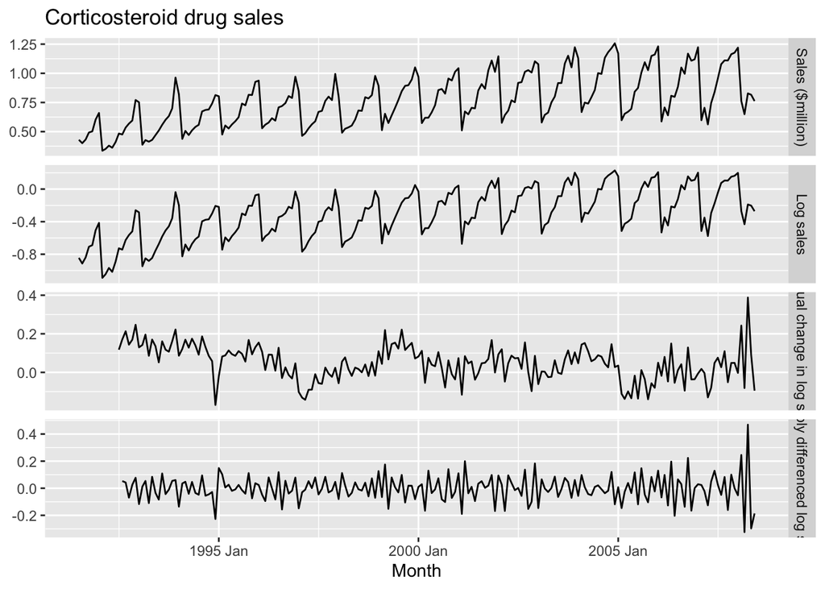

```r
PBS |>
  filter(ATC2 == "H02") |>
  summarise(Cost = sum(Cost)/1e6) |>
  transmute(
    `Sales ($million)` = Cost,
    `Log sales` = log(Cost),
    `Annual change in log sales` = difference(log(Cost), 12),
    `Doubly differenced log sales` =
                     difference(difference(log(Cost), 12), 1)
  ) |>
  pivot_longer(-Month, names_to="Type", values_to="Sales") |>
  mutate(
    Type = factor(Type, levels = c(
      "Sales ($million)",
      "Log sales",
      "Annual change in log sales",
      "Doubly differenced log sales"))
  ) |>
  ggplot(aes(x = Month, y = Sales)) +
  geom_line() +
  facet_grid(vars(Type), scales = "free_y") +
  labs(title = "Corticosteroid drug sales", y = NULL)
```

Figure 9.4: Top panel: Corticosteroid drug sales ($AUD). Other panels show the same data after transforming and differencing.

#### 계절 + 1차 차분의 순서

- **차분 순서는 결과에 영향을 주지 않음**

$$y''_t = (y_t - y_{t-m}) - (y_{t-1} - y_{t-m-1}) = y_t - y_{t-1}
- y_{t-m} + y_{t-m-1}$$

- **계절성이 강한 경우**, 먼저 **계절 차분**을 적용하는 것이 좋음
- 불필요한 차분은 **가짜 자기상관(false autocorrelation)**을 유발할 수 있음 → 최소한의 차분만 사용

#### 해석 가능한 차분 사용

- **1차 차분**: 시점 간 변화
- **계절 차분**: 작년 같은 시점 대비 변화
- 그 외 불명확한 시차(lag)에 의한 차분은 **해석력 부족** → 피하는 것이 좋음

### 단위근 검정: KPSS Test

- **객관적인 차분 필요 여부** 판단 도구
- **KPSS 검정 (Kwiatkowski–Phillips–Schmidt–Shin)**
  - 귀무가설: **정상 시계열임**
  - $p$-값이 **작을수록** (예: < 0.05), **차분이 필요함**

#### 예시: Google 주가에 대한 KPSS 검정

```r
google_2015 |>
  features(Close, unitroot_kpss)
```

```
## # A tibble: 1 × 3
##   Symbol kpss_stat kpss_pvalue
##   <chr>      <dbl>       <dbl>
## 1 GOOG        3.56        0.01
```

- KPSS 검정의 p-value는 0.01 ~ 0.1 사이로 표시됨
  - 실제 p-value < 0.01 → 0.01로 표시
  - 실제 p-value > 0.1 → 0.1로 표시
- p-value가 0.01로 나타난 경우, 실제로는 0.01보다 작을 수도 있음 → **귀무가설(정상성)**을 기각함 → 데이터는 비정상
- 이 경우, 데이터를 차분한 후 다시 KPSS 검정을 수행해야 함

```r
google_2015 |>
  mutate(diff_close = difference(Close)) |>
  features(diff_close, unitroot_kpss)
```

```
## # A tibble: 1 × 3
##   Symbol kpss_stat kpss_pvalue
##   <chr>      <dbl>       <dbl>
## 1 GOOG      0.0989         0.1
```

- 이번에는 p-value가 0.1로 보고됨 → 실제로는 0.1보다 클 수도 있음
- 따라서 귀무가설(정상성)을 기각할 수 없음 → **차분된 데이터는 정상적(stationary)**이라고 판단함
- 이처럼 KPSS 검정을 반복 적용하여 필요한 1차 차분 횟수를 자동으로 판단하는 기능이 바로 unitroot_ndiffs()이다.

```r
google_2015 |>
  features(Close, unitroot_ndiffs)
```

```
## # A tibble: 1 × 2
##   Symbol ndiffs
##   <chr>   <int>
## 1 GOOG        1
```

- 앞서 본 KPSS 검정 결과에 따르면, google_2015 데이터에는 1차 차분 한 번이 필요함
- **계절 차분(seasonal differencing)**이 필요한지 자동으로 판단하는 기능은 unitroot_nsdiffs()

작동 원리:

- 계절 강도 지표 $F_S$ (Section 4.3 기반)를 사용함
- 기준:
  - $F_S < 0.64$ → 계절 차분 불필요
  - $F_S ≥ 0.64$ → 계절 차분 1회 권장
- 예시: unitroot_nsdiffs()를 호주의 월별 소매 판매액 데이터에 적용 가능

```r
aus_total_retail <- aus_retail |>
  summarise(Turnover = sum(Turnover))
aus_total_retail |>
  mutate(log_turnover = log(Turnover)) |>
  features(log_turnover, unitroot_nsdiffs)
```

```
## # A tibble: 1 × 1
##   nsdiffs
##     <int>
## 1       1
```

```r
aus_total_retail |>
  mutate(log_turnover = difference(log(Turnover), 12)) |>
  features(log_turnover, unitroot_ndiffs)
```

```
## # A tibble: 1 × 1
##   ndiffs
##    <int>
## 1      1
```

unitroot_nsdiffs() 함수가 1을 반환했다는 것은 한 번의 계절 차분이 필요함을 의미한다. 따라서, 계절 차분을 적용한 후, unitroot_ndiffs() 함수를 다시 사용하여 1차 차분이 필요한지도 확인한다.

이 두 함수의 결과는 계절 차분과 1차 차분을 모두 수행해야 함을 시사한다.